# global map

Nick McManus

2022-08-01

## Read in data

This analysis will require data sets of protected areas from the WDPA, urban-classified land use, and sites from the UNESCO World Heritage Convention. WDPA and urban areas are currently excluded from agriculture and energy land use within the current SPARCLE workflow. Because UNESCO WHC sites are protected, these locations must also be excluded, or “locked out” from the SPARCLE process. The purpose of this script is to determine how many cultural heritage sites *do not* overlap with either a WDPA or urban area (at 5km resolution) *and* are larger than 100ha (1 km2) in area.

### WDPA data

UNEP-WCMC and IUCN (2021), Protected Planet: The World Database on Protected Areas (WDPA) [On-line], Cambridge, UK: UNEP-WCMC and IUCN. Available at: www.protectedplanet.net

```r
# read in 5km resolution WDPA layer
wdpa <- rast(here("data", "wdpa_5km_raster.tif"))

# set desired crs to match wdpa layer
my_crs <- st_crs(wdpa)
```

### Urban data

Current (2015) areas classified as urban under Chen et al., 2022 Chen, G., Li, X., & Liu, X. (2022). Global land projection based on plant functional types with a 1-km resolution under socio-climatic scenarios. Scientific Data, 9(1), 125. https://doi.org/10.1038/s41597-022-01208-6

```r
# read in 5km resolution urban Chen data
urban <- rast(here("data", "chen_urban_5km.tif")) %>%
  project(y = wdpa) # make urban and wdpa same crs
```

### UNESCO data

For this dataset, we will only be examining “cultural” heritage sites. The boundaries for sites classified as “natural” or “mixed” are included in the WDPA. Copyright © 1992 - 2022 UNESCO/World Heritage Centre. All rights reserved. https://whc.unesco.org/en/syndication

```r
# read in cultural heritage sites
unesco <- read_csv(here("data", "whc-sites-2021.csv")) %>%
  filter(category == "Cultural") %>%
  st_as_sf(coords = c("longitude", "latitude"),
           crs = st_crs("epsg:4326")) %>%
  st_transform(crs = my_crs) %>%
  dplyr::select(name_en, area_hectares, states_name_en) %>%
  mutate(ID = row_number()) %>%  # define id for joining later
  rename(country = states_name_en)
```

## Define overlaps

### UNESCO + WDPA

Determine where cultural heritage sites overlap with existing protected areas in the WDPA.

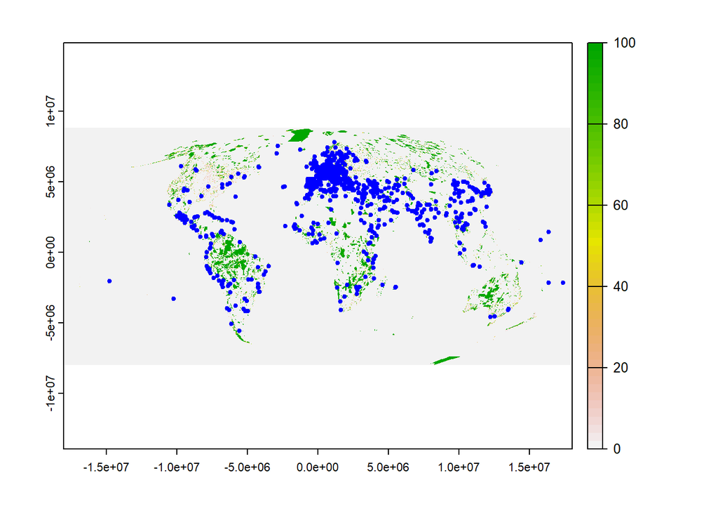

```r
# vect easier to use with raster
unesco_vect <- vect(unesco)

plot(wdpa)
plot(unesco_vect, col = "blue", cex = 0.8, add = TRUE)
```

```r
# use extract() to extract what's underneath points
wdpa_overlap <- terra::extract(
  x = wdpa,
  y = unesco_vect) %>%
  # extract what's under the points in the raster

  rename(wdpa_overlap = 2) %>%
  # rename second column to 'urban_overlap'

  mutate(wdpa_overlap = as.logical(wdpa_overlap)) %>%
  # extract() outputs the values of the raster (or a summary thereof)
  # change to true/false

  right_join(unesco, by = "ID") %>%
  # the df from extract only contains ID numbers and raster values,
  # this joins the dataframe back up with the site names by linking the ID
  # numbers in the two tables

  dplyr::select(!c(geometry, ID)) %>%
  # remove columns we don't care about

  relocate(name_en, .before = wdpa_overlap)
  # move columns into desired order


kable(wdpa_overlap) %>%
  kable_styling(bootstrap_options = "striped") %>%
  scroll_box(height = "400px")
```

| name_en | wdpa_overlap | area_hectares | country |
| --- | --- | --- | --- |
| Cultural Landscape and Archaeological Remains of the Bamiyan Valley | FALSE | 158.9265 | Afghanistan |
| Minaret and Archaeological Remains of Jam | FALSE | 70.0000 | Afghanistan |
| Historic Centres of Berat and Gjirokastra | FALSE | 58.9000 | Albania |
| Butrint | TRUE | NA | Albania |
| Al Qal’a of Beni Hammad | FALSE | 150.0000 | Algeria |
| M’Zab Valley | FALSE | 665.0300 | Algeria |
| Dj<e9>mila | FALSE | 30.6000 | Algeria |
| Tipasa | FALSE | 52.1600 | Algeria |
| Timgad | FALSE | 90.5400 | Algeria |
| Kasbah of Algiers | FALSE | 54.7000 | Algeria |
| Madriu-Perafita-Claror Valley | TRUE | 4247.0000 | Andorra |
| Mbanza Kongo, Vestiges of the Capital of the former Kingdom of Kongo | FALSE | 89.2900 | Angola |
| Antigua Naval Dockyard and Related Archaeological Sites | TRUE | 255.0000 | Antigua and Barbuda |
| Cueva de las Manos, R<ed>o Pinturas | TRUE | 600.0000 | Argentina |
| Jesuit Block and Estancias of C<f3>rdoba | FALSE | 38.1200 | Argentina |
| Quebrada de Humahuaca | TRUE | 172116.4375 | Argentina |
| Monasteries of Haghpat and Sanahin | FALSE | 2.6500 | Armenia |
| Monastery of Geghard and the Upper Azat Valley | TRUE | 2.7000 | Armenia |
| Cathedral and Churches of Echmiatsin and the Archaeological Site of Zvartnots | FALSE | 74.3000 | Armenia |
| Sydney Opera House | FALSE | 5.8000 | Australia |
| Royal Exhibition Building and Carlton Gardens | FALSE | 26.0000 | Australia |
| Australian Convict Sites | TRUE | 1502.5100 | Australia |
| Budj Bim Cultural Landscape | TRUE | 9935.0000 | Australia |
| Historic Centre of the City of Salzburg | TRUE | 236.0000 | Austria |
| Semmering Railway | TRUE | 156.1800 | Austria |
| Palace and Gardens of Sch<f6>nbrunn | TRUE | 186.2800 | Austria |
| Hallstatt-Dachstein / Salzkammergut Cultural Landscape | TRUE | 28446.2000 | Austria |
| City of Graz  Historic Centre and Schloss Eggenberg | TRUE | NA | Austria |
| Wachau Cultural Landscape | TRUE | 18387.0000 | Austria |
| Historic Centre of Vienna | FALSE | 371.0000 | Austria |

[output cut: 868 more lines]

### UNESCO + Urban

Determine where cultural heritage sites overlap with existing urban areas.

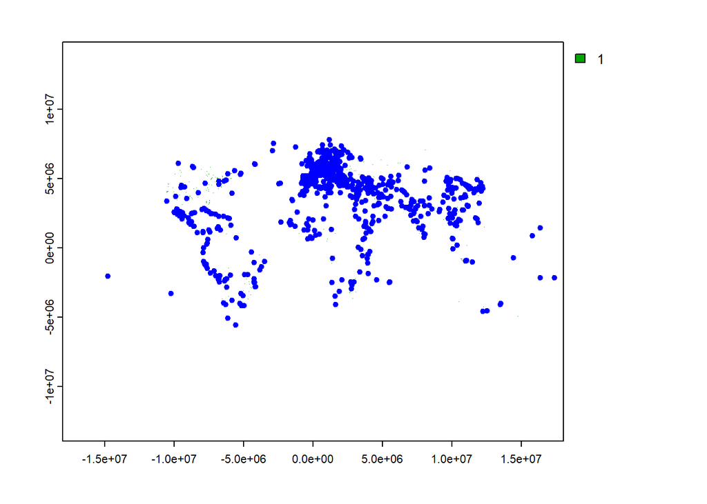

```r
plot(urban)
plot(unesco_vect, col = "blue", add = TRUE)
```

```r
urban_overlap <- terra::extract(x = urban, y = unesco_vect) %>%
  rename(urban_overlap = 2) %>%
  mutate(urban_overlap = as.logical(urban_overlap)) %>%
  right_join(unesco, by = "ID") %>%
  dplyr::select(!c(geometry, ID)) %>%
  relocate(name_en, .before = urban_overlap)

# change NAs to FALSE for filtering later
urban_overlap[is.na(urban_overlap)] <- FALSE

kable(urban_overlap) %>%
  kable_styling(bootstrap_options = "striped") %>%
  scroll_box(height = "400px")
```

| name_en | urban_overlap | area_hectares | country |
| --- | --- | --- | --- |
| Cultural Landscape and Archaeological Remains of the Bamiyan Valley | FALSE | 158.9265 | Afghanistan |
| Minaret and Archaeological Remains of Jam | FALSE | 70.0000 | Afghanistan |
| Historic Centres of Berat and Gjirokastra | FALSE | 58.9000 | Albania |
| Butrint | FALSE | 0.0000 | Albania |
| Al Qal’a of Beni Hammad | FALSE | 150.0000 | Algeria |
| M’Zab Valley | TRUE | 665.0300 | Algeria |
| Dj<e9>mila | FALSE | 30.6000 | Algeria |
| Tipasa | FALSE | 52.1600 | Algeria |
| Timgad | FALSE | 90.5400 | Algeria |
| Kasbah of Algiers | TRUE | 54.7000 | Algeria |
| Madriu-Perafita-Claror Valley | FALSE | 4247.0000 | Andorra |
| Mbanza Kongo, Vestiges of the Capital of the former Kingdom of Kongo | FALSE | 89.2900 | Angola |
| Antigua Naval Dockyard and Related Archaeological Sites | FALSE | 255.0000 | Antigua and Barbuda |
| Cueva de las Manos, R<ed>o Pinturas | FALSE | 600.0000 | Argentina |
| Jesuit Block and Estancias of C<f3>rdoba | TRUE | 38.1200 | Argentina |
| Quebrada de Humahuaca | FALSE | 172116.4375 | Argentina |
| Monasteries of Haghpat and Sanahin | FALSE | 2.6500 | Armenia |
| Monastery of Geghard and the Upper Azat Valley | FALSE | 2.7000 | Armenia |
| Cathedral and Churches of Echmiatsin and the Archaeological Site of Zvartnots | FALSE | 74.3000 | Armenia |
| Sydney Opera House | TRUE | 5.8000 | Australia |
| Royal Exhibition Building and Carlton Gardens | TRUE | 26.0000 | Australia |
| Australian Convict Sites | FALSE | 1502.5100 | Australia |
| Budj Bim Cultural Landscape | FALSE | 9935.0000 | Australia |
| Historic Centre of the City of Salzburg | TRUE | 236.0000 | Austria |
| Semmering Railway | FALSE | 156.1800 | Austria |
| Palace and Gardens of Sch<f6>nbrunn | TRUE | 186.2800 | Austria |
| Hallstatt-Dachstein / Salzkammergut Cultural Landscape | FALSE | 28446.2000 | Austria |
| City of Graz  Historic Centre and Schloss Eggenberg | TRUE | 0.0000 | Austria |
| Wachau Cultural Landscape | FALSE | 18387.0000 | Austria |
| Historic Centre of Vienna | TRUE | 371.0000 | Austria |

[output cut: 868 more lines]

## Combine

We are interested in sites that return FALSE for both urban and WDPA overlaps. Therefore, we must join the previous results.

```r
wdpa_urban_overlap <- wdpa_overlap %>%
  left_join(urban_overlap, by = NULL) %>%
  relocate(urban_overlap, .before = area_hectares)

# remove NA values for easier filtering later
wdpa_urban_overlap[is.na(wdpa_urban_overlap)] <- FALSE

kable(wdpa_urban_overlap) %>%
  kable_styling(bootstrap_options = "striped") %>%
  scroll_box(height = "400px")
```

| name_en | wdpa_overlap | urban_overlap | area_hectares | country |
| --- | --- | --- | --- | --- |
| Cultural Landscape and Archaeological Remains of the Bamiyan Valley | FALSE | FALSE | 158.9265 | Afghanistan |
| Minaret and Archaeological Remains of Jam | FALSE | FALSE | 70.0000 | Afghanistan |
| Historic Centres of Berat and Gjirokastra | FALSE | FALSE | 58.9000 | Albania |
| Butrint | TRUE | FALSE | 0.0000 | Albania |
| Al Qal’a of Beni Hammad | FALSE | FALSE | 150.0000 | Algeria |
| M’Zab Valley | FALSE | TRUE | 665.0300 | Algeria |
| Dj<e9>mila | FALSE | FALSE | 30.6000 | Algeria |
| Tipasa | FALSE | FALSE | 52.1600 | Algeria |
| Timgad | FALSE | FALSE | 90.5400 | Algeria |
| Kasbah of Algiers | FALSE | TRUE | 54.7000 | Algeria |
| Madriu-Perafita-Claror Valley | TRUE | FALSE | 4247.0000 | Andorra |
| Mbanza Kongo, Vestiges of the Capital of the former Kingdom of Kongo | FALSE | FALSE | 89.2900 | Angola |
| Antigua Naval Dockyard and Related Archaeological Sites | TRUE | FALSE | 255.0000 | Antigua and Barbuda |
| Cueva de las Manos, R<ed>o Pinturas | TRUE | FALSE | 600.0000 | Argentina |
| Jesuit Block and Estancias of C<f3>rdoba | FALSE | TRUE | 38.1200 | Argentina |
| Quebrada de Humahuaca | TRUE | FALSE | 172116.4375 | Argentina |
| Monasteries of Haghpat and Sanahin | FALSE | FALSE | 2.6500 | Armenia |
| Monastery of Geghard and the Upper Azat Valley | TRUE | FALSE | 2.7000 | Armenia |
| Cathedral and Churches of Echmiatsin and the Archaeological Site of Zvartnots | FALSE | FALSE | 74.3000 | Armenia |
| Sydney Opera House | FALSE | TRUE | 5.8000 | Australia |
| Royal Exhibition Building and Carlton Gardens | FALSE | TRUE | 26.0000 | Australia |
| Australian Convict Sites | TRUE | FALSE | 1502.5100 | Australia |
| Budj Bim Cultural Landscape | TRUE | FALSE | 9935.0000 | Australia |
| Historic Centre of the City of Salzburg | TRUE | TRUE | 236.0000 | Austria |
| Semmering Railway | TRUE | FALSE | 156.1800 | Austria |
| Palace and Gardens of Sch<f6>nbrunn | TRUE | TRUE | 186.2800 | Austria |
| Hallstatt-Dachstein / Salzkammergut Cultural Landscape | TRUE | FALSE | 28446.2000 | Austria |
| City of Graz  Historic Centre and Schloss Eggenberg | TRUE | FALSE | 0.0000 | Austria |
| Wachau Cultural Landscape | TRUE | FALSE | 18387.0000 | Austria |
| Historic Centre of Vienna | FALSE | TRUE | 371.0000 | Austria |

[output cut: 868 more lines]

## Filter UNESCO sites

Now, we want to return only cultural heritage sites that do not overlap with either the urban or WDPA layers *and* are at least 100ha in size.

```r
# filter combined data
unesco_filtered <- wdpa_urban_overlap %>%
  filter(wdpa_overlap == FALSE,
         urban_overlap == FALSE) %>%
  filter(area_hectares >= 100)


kable(unesco_filtered) %>%
  kable_styling(bootstrap_options = "striped") %>%
  scroll_box(height = "400px")
```

| name_en | wdpa_overlap | urban_overlap | area_hectares | country |
| --- | --- | --- | --- | --- |
| Cultural Landscape and Archaeological Remains of the Bamiyan Valley | FALSE | FALSE | 158.9265 | Afghanistan |
| Al Qal’a of Beni Hammad | FALSE | FALSE | 150.0000 | Algeria |
| Gobustan Rock Art Cultural Landscape | FALSE | FALSE | 537.2200 | Azerbaijan |
| Historic Centre of Sheki with the Khans Palace | FALSE | FALSE | 120.5000 | Azerbaijan |
| Historic Bridgetown and its Garrison | FALSE | FALSE | 187.0000 | Barbados |
| City of Potos<ed> | FALSE | FALSE | 2211.0000 | Bolivia (Plurinational State of) |
| Ancient Ferrous Metallurgy Sites of Burkina Faso | FALSE | FALSE | 122.3000 | Burkina Faso |
| Cidade Velha, Historic Centre of Ribeira Grande | FALSE | FALSE | 209.1000 | Cabo Verde |
| LAnse aux Meadows National Historic Site | FALSE | FALSE | 7991.0000 | Canada |
| Head-Smashed-In Buffalo Jump | FALSE | FALSE | 3626.0000 | Canada |
| Rideau Canal | FALSE | FALSE | 21454.8100 | Canada |
| Red Bay Basque Whaling Station | FALSE | FALSE | 312.9730 | Canada |
| Humberstone and Santa Laura Saltpeter Works | FALSE | FALSE | 573.4800 | Chile |
| Settlement and Artificial Mummification of the Chinchorro Culture in the Arica and Parinacota Region | FALSE | FALSE | 364.0500 | Chile |
| The Great Wall | FALSE | FALSE | 2151.5500 | China |
| Mogao Caves | FALSE | FALSE | 23392.0000 | China |
| Mausoleum of the First Qin Emperor | FALSE | FALSE | 244.0000 | China |
| Lushan National Park | FALSE | FALSE | 30200.0000 | China |
| Old Town of Lijiang | FALSE | FALSE | 145.6000 | China |
| Summer Palace, an Imperial Garden in Beijing | FALSE | FALSE | 297.0000 | China |
| Longmen Grottoes | FALSE | FALSE | 331.0000 | China |
| Imperial Tombs of the Ming and Qing Dynasties | FALSE | FALSE | 3434.9399 | China |
| Yungang Grottoes | FALSE | FALSE | 348.7500 | China |
| Cultural Landscape of Honghe Hani Rice Terraces | FALSE | FALSE | 16603.2200 | China |
| Kaiping Diaolou and Villages | FALSE | FALSE | 371.9480 | China |
| Fujian <em>Tulou</em> | FALSE | FALSE | 152.6500 | China |
| Capital Cities and Tombs of the Ancient Koguryo Kingdom | FALSE | FALSE | 4164.8599 | China |
| Mount Wutai | FALSE | FALSE | 18415.0000 | China |
| Historic Monuments of Dengfeng in The Centre of Heaven and Earth | FALSE | FALSE | 825.0000 | China |
| West Lake Cultural Landscape of Hangzhou | FALSE | FALSE | 3322.8800 | China |

[output cut: 154 more lines]

Combine back with original data to get coordinates of filtered sites

```r
# read in original UNESCO csv
raw <- read_csv(here("data", "whc-sites-2021.csv")) %>%
  filter(category == "Cultural")

# join filtered sites with raw csv to assign lat/long data to each unesco site
raw_unesco_joined <- left_join(unesco_filtered, raw, by = c("name_en", "area_hectares"))

# assign CRS and keep only variables of interest
unesco_filtered_geom <- raw_unesco_joined %>%
  st_as_sf(coords = c("longitude", "latitude"),
           crs = st_crs("epsg:4326")) %>%
  st_transform(crs = my_crs) %>%
  dplyr::select(name_en, area_hectares, wdpa_overlap, urban_overlap, country, geometry)

# turn into vector for plotting
unesco_filtered_vect <- vect(unesco_filtered_geom)
```

Plot the results

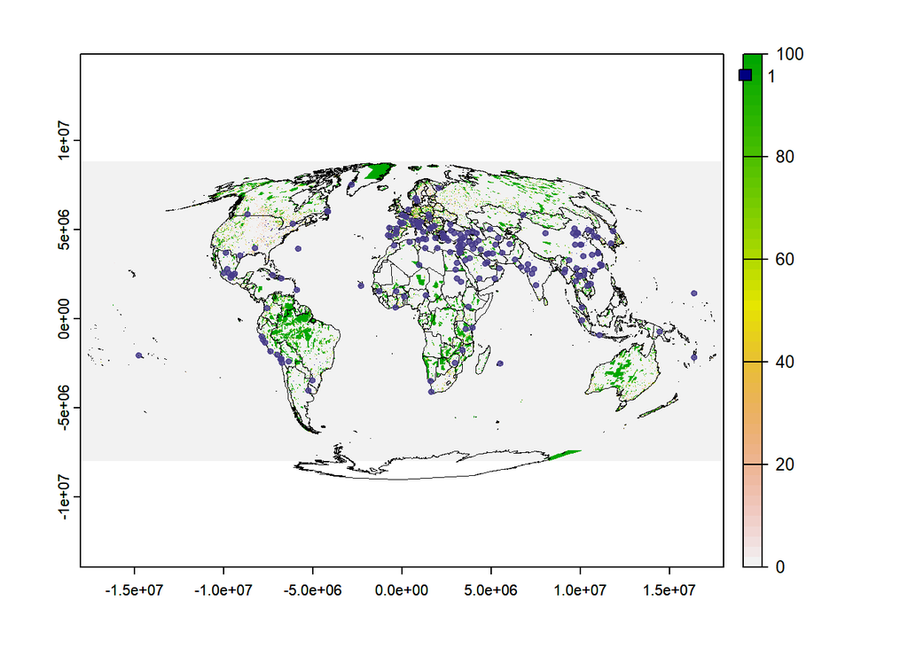

```r
# get country outlines from rnaturalearth
world <- ne_countries(scale = "medium", returnclass = "sf") %>%
  st_transform(crs = crs(wdpa)) # make same crs as rest of data

plot(wdpa)
plot(urban, col = "navyblue", add = TRUE)  #pretty hard to see since so small
plot(world, col = NA, lwd = 0.8, add = TRUE)
plot(unesco_filtered_vect, col = "slateblue4", alpha = 0.8, cex =0.9, add = TRUE)
```

## Analysis

Now we are interested in the size (in hectares) of the remaining cultural heritage sites.

```r
# overall stats of remaining cultural sites
mean_size_ha <- round(mean(unesco_filtered$area_hectares), 2)
median_size_ha <- round(median(unesco_filtered$area_hectares), 2)
sd_size_ha <- round(sd(unesco_filtered$area_hectares), 2)
n <- count(unesco_filtered)
min_size <- round(min(unesco_filtered$area_hectares),2)
max_size <- round(max(unesco_filtered$area_hectares),2)

# how many sites were there originally?
n_raw <- count(raw)
```

Of the 898 UNESCO cultural heritage sites, 184 do not overlap with urban or WDPA areas and are at least 100ha large. These remaining sites range in size from 103ha to 3.923961^{6}ha. The mean size is 3.273451^{4}ha $\pm$ 2.9127088^{5}ha (mean $\pm$ std dev) with a median size of 599.92ha. Sample statistics summarized by country are returned below:

```r
# look by country
unesco_filtered_stats <- unesco_filtered %>%
  group_by(country) %>%
  summarise(mean_area_ha = round(mean(area_hectares), 2),
            sd_area_ha = round(sd(area_hectares), 2),
            median_size_ha = round(median(area_hectares), 2),
            n = n()) %>%
  relocate(n, .before = mean_area_ha)

# return summary table
kable(unesco_filtered_stats) %>%
  kable_styling(bootstrap_options = "striped") %>%
  scroll_box(height = "400px")
```

| country | n | mean_area_ha | sd_area_ha | median_size_ha |
| --- | --- | --- | --- | --- |
| Afghanistan | 1 | 158.93 | NA | 158.93 |
| Algeria | 1 | 150.00 | NA | 150.00 |
| Argentina,Bolivia (Plurinational State of),Chile,Colombia,Ecuador,Peru | 1 | 3642.81 | NA | 3642.81 |
| Argentina,Brazil | 1 | 265.09 | NA | 265.09 |
| Azerbaijan | 2 | 328.86 | 294.67 | 328.86 |
| Barbados | 1 | 187.00 | NA | 187.00 |
| Bolivia (Plurinational State of) | 1 | 2211.00 | NA | 2211.00 |
| Burkina Faso | 1 | 122.30 | NA | 122.30 |
| C<f4>te d’Ivoire | 1 | 109.89 | NA | 109.89 |
| Cabo Verde | 1 | 209.10 | NA | 209.10 |
| Canada | 4 | 8346.20 | 9287.53 | 5808.50 |
| Chile | 2 | 468.76 | 148.09 | 468.76 |
| China | 22 | 6328.20 | 9555.67 | 1129.33 |
| Colombia | 1 | 141120.00 | NA | 141120.00 |
| Cuba | 1 | 81475.00 | NA | 81475.00 |
| Democratic People’s Republic of Korea | 2 | 364.46 | 183.47 | 364.46 |
| Denmark | 1 | 417800.00 | NA | 417800.00 |
| Dominican Republic | 1 | 106.00 | NA | 106.00 |
| Egypt | 3 | 2649.12 | 4106.98 | 374.48 |
| Ethiopia | 1 | 23000.00 | NA | 23000.00 |
| France | 7 | 4057.55 | 6344.81 | 1070.00 |
| Greece | 2 | 386.98 | 397.92 | 386.98 |
| Hungary | 1 | 144.50 | NA | 144.50 |
| India | 6 | 2748.36 | 3034.62 | 1610.95 |
| Indonesia | 2 | 2934.09 | 3770.17 | 2934.09 |
| Iran (Islamic Republic of) | 9 | 14793.19 | 34858.73 | 716.35 |
| Iraq | 3 | 5478.68 | 8303.97 | 1054.30 |
| Israel | 1 | 6655.00 | NA | 6655.00 |
| Italy | 11 | 11196.91 | 21602.45 | 898.46 |
| Japan | 2 | 335.53 | 273.84 | 335.53 |
| Jordan | 2 | 13232.58 | 18297.69 | 13232.58 |
| Kenya | 1 | 1538.00 | NA | 1538.00 |
| Lao People’s Democratic Republic | 3 | 13331.52 | 22231.90 | 820.00 |
| Lebanon | 2 | 937.00 | 1107.61 | 937.00 |
| Libya | 3 | 1308160.05 | 2265350.07 | 387.48 |
| Malawi | 1 | 12640.00 | NA | 12640.00 |
| Malaysia | 1 | 398.64 | NA | 398.64 |
| Marshall Islands | 1 | 73500.00 | NA | 73500.00 |
| Mauritius | 1 | 349.60 | NA | 349.60 |
| Mexico | 8 | 5659.81 | 12060.61 | 478.82 |
| Mongolia | 1 | 11300.00 | NA | 11300.00 |
| Montenegro | 1 | 14600.00 | NA | 14600.00 |
| Morocco | 1 | 280.00 | NA | 280.00 |
| Myanmar | 2 | 5407.24 | 568.17 | 5407.24 |
| Netherlands | 1 | 7208.00 | NA | 7208.00 |
| Nigeria | 1 | 764.40 | NA | 764.40 |
| Oman | 2 | 1152.91 | 428.56 | 1152.91 |
| Pakistan | 1 | 240.00 | NA | 240.00 |
| Papua New Guinea | 1 | 116.00 | NA | 116.00 |
| Peru | 5 | 16409.18 | 32996.53 | 1414.57 |
| Poland | 1 | 380.00 | NA | 380.00 |
| Portugal | 2 | 696.26 | 731.02 | 696.26 |
| Qatar | 1 | 415.66 | NA | 415.66 |
| Russian Federation | 1 | 28834.00 | NA | 28834.00 |
| Saudi Arabia | 4 | 3112.79 | 3701.62 | 1832.50 |
| Senegal | 1 | 50309.00 | NA | 50309.00 |
| Serbia | 2 | 188.97 | 13.79 | 188.97 |
| South Africa | 2 | 80237.50 | 112801.21 | 80237.50 |
| Spain | 4 | 196.46 | 88.44 | 197.06 |
| Sudan | 2 | 1269.93 | 1537.86 | 1269.93 |
| Sweden | 2 | 2123.35 | 2848.59 | 2123.35 |
| Switzerland | 1 | 898.00 | NA | 898.00 |
| Syrian Arab Republic | 3 | 4682.07 | 6632.57 | 1640.00 |
| Thailand | 1 | 11852.00 | NA | 11852.00 |
| Togo | 1 | 50000.00 | NA | 50000.00 |
| Tunisia | 1 | 498.08 | NA | 498.08 |
| Turkey | 11 | 437.01 | 551.08 | 250.70 |
| Turkmenistan | 2 | 353.24 | 0.00 | 353.24 |
| Ukraine | 1 | 259.38 | NA | 259.38 |
| United Kingdom of Great Britain and Northern Ireland | 1 | 257.50 | NA | 257.50 |
| United Republic of Tanzania | 1 | 233600.00 | NA | 233600.00 |
| United States of America | 2 | 231.90 | 97.44 | 231.90 |
| Uruguay | 1 | 273.80 | NA | 273.80 |
| Vanuatu | 1 | 886.31 | NA | 886.31 |
| Viet Nam | 2 | 148.75 | 9.55 | 148.75 |
| Zimbabwe | 1 | 722.00 | NA | 722.00 |